title: "Module 05: Lab 02" subtitle: "Regression Modeling on Employment Data" author:

- name: Marco Perez affiliations:
  - name: Boston University city: Boston state: MA number-sections: true date: "2024-04-16" format: html: theme: flatly toc: true toc-depth: 2 date-modified: today date-format: long execute: echo: false eval: false freeze: auto

# Objectives {.unnumbered}

1. Use **PySpark** to process the Lightcast dataset.
2. Engineer features from structured columns for salary prediction.
3. Train **Linear Regression model**.
4. Evaluate models using **RMSE** and **R²**.
5. Visualize predictions using diagnostic plots.
6. Push work to GitHub and submit the repository link.

# Setup {.unnumbered}

The instruction below provides you with general keywords for columns used in the lightcast file. See the data schema generated after the load dataset code above to use proper column name. For visualizations, tables, or summaries, please **customize colors, fonts, and styles** as appropriate to avoid a **2.5-point deduction**. Also, **provide a two-sentence explanation** describing key insights drawn from each section's code and outputs.

1. Follow the steps below as necessary, use your best judgement in importing/installing/creating/saving files as needed.
2. Create a new Jupyter Notebook in your `ad688-sp25-lab08` directory named `lab08_yourname.ipynb`, if the file exists make sure to change the name.
3. Use your **EC2 instance** for this lab.
4. Ensure the `lightcast_data.csv` file is available on the EC2 instance. if not then **Download the dataset**
5. **Add the dataset to `.gitignore`** to avoid pushing large files to GitHub. Open your `.gitignore` file and add:
6. Make sure to create a virtual environment and install the required Python libraries if needed, don't forget to activate it:
7. Install the required Python libraries if needed, you can also use the given requirement file to install the packages to the virtual environment:

```
python3 -m venv .venv
source .venv/bin/activate
gdown https://drive.google.com/uc?id=1V2GCHGt2dkFGqVBeoUFckU4IhUgk4ocQ
echo "lightcast_job_postings.csv" >> .gitignore
pip install -r requirements.txt
```

# Load the Dataset

1. **Load the Raw Dataset**:
   - Use Pyspark to the `lightcast_data.csv` file into a DataFrame:
   - You can reuse the previous code.
   - [Copying code from your friend constitutes plagiarism. DO NOT DO THIS]{.uured-bold}.

```python
#| eval: true
#| echo: true
from pyspark.sql import SparkSession
import pandas as pd
import plotly.express as px
import plotly.io as pio
pio.renderers.default = "notebook"

# Initialize Spark Session
spark = SparkSession.builder.appName("LightcastData").getOrCreate()

# Load Data
df = spark.read.option("header", "true").option("inferSchema", "true").option("multiLine","true").option("escape", "\"").csv("./data/lightcast_job_postings.csv")

# Show Schema and Sample Data
print("---This is Diagnostic check, No need to print it in the final doc---")

df.printSchema() # comment this line when rendering the submission
df.show(5)
```

```
---This is Diagnostic check, No need to print it in the final doc---
root
 |-- ID: string (nullable = true)
 |-- LAST_UPDATED_DATE: string (nullable = true)
 |-- LAST_UPDATED_TIMESTAMP: timestamp (nullable = true)
 |-- DUPLICATES: integer (nullable = true)
 |-- POSTED: string (nullable = true)
 |-- EXPIRED: string (nullable = true)
 |-- DURATION: integer (nullable = true)
 |-- SOURCE_TYPES: string (nullable = true)
 |-- SOURCES: string (nullable = true)
 |-- URL: string (nullable = true)
 |-- ACTIVE_URLS: string (nullable = true)
 |-- ACTIVE_SOURCES_INFO: string (nullable = true)
 |-- TITLE_RAW: string (nullable = true)
 |-- BODY: string (nullable = true)
 |-- MODELED_EXPIRED: string (nullable = true)
 |-- MODELED_DURATION: integer (nullable = true)
 |-- COMPANY: integer (nullable = true)
 |-- COMPANY_NAME: string (nullable = true)
 |-- COMPANY_RAW: string (nullable = true)
 |-- COMPANY_IS_STAFFING: boolean (nullable = true)
 |-- EDUCATION_LEVELS: string (nullable = true)
 |-- EDUCATION_LEVELS_NAME: string (nullable = true)
 |-- MIN_EDULEVELS: integer (nullable = true)
 |-- MIN_EDULEVELS_NAME: string (nullable = true)
 |-- MAX_EDULEVELS: integer (nullable = true)
 |-- MAX_EDULEVELS_NAME: string (nullable = true)
 |-- EMPLOYMENT_TYPE: integer (nullable = true)
 |-- EMPLOYMENT_TYPE_NAME: string (nullable = true)
 |-- MIN_YEARS_EXPERIENCE: integer (nullable = true)
 |-- MAX_YEARS_EXPERIENCE: integer (nullable = true)
 |-- IS_INTERNSHIP: boolean (nullable = true)
 |-- SALARY: integer (nullable = true)
 |-- REMOTE_TYPE: integer (nullable = true)
 |-- REMOTE_TYPE_NAME: string (nullable = true)
 |-- ORIGINAL_PAY_PERIOD: string (nullable = true)
 |-- SALARY_TO: integer (nullable = true)
 |-- SALARY_FROM: integer (nullable = true)
 |-- LOCATION: string (nullable = true)
```

[output cut: 89 more lines]

```
 |-- NAICS_2022_5: integer (nullable = true)
 |-- NAICS_2022_5_NAME: string (nullable = true)
 |-- NAICS_2022_6: integer (nullable = true)
 |-- NAICS_2022_6_NAME: string (nullable = true)

+--------------------+-----------------+----------------------+----------+--------+---------+--------+--------------------+--------------------+--------------------+-----------+-------------------+--------------------+--------------------+---------------+----------------+--------+-------------------…
|                  ID|LAST_UPDATED_DATE|LAST_UPDATED_TIMESTAMP|DUPLICATES|  POSTED|  EXPIRED|DURATION|        SOURCE_TYPES|             SOURCES|                 URL|ACTIVE_URLS|ACTIVE_SOURCES_INFO|           TITLE_RAW|                BODY|MODELED_EXPIRED|MODELED_DURATION| COMPANY|        COMPANY_NAM…
+--------------------+-----------------+----------------------+----------+--------+---------+--------+--------------------+--------------------+--------------------+-----------+-------------------+--------------------+--------------------+---------------+----------------+--------+-------------------…
|1f57d95acf4dc67ed...|         9/6/2024|  2024-09-06 20:32:...|         0|6/2/2024| 6/8/2024|       6|   [\n  "Company"\n]|[\n  "brassring.c...|[\n  "https://sjo...|         []|               NULL|Enterprise Analys...|31-May-2024\n\nEn...|       6/8/2024|               6|  894731|          Murphy US…
|0cb072af26757b6c4...|         8/2/2024|  2024-08-02 17:08:...|         0|6/2/2024| 8/1/2024|    NULL| [\n  "Job Board"\n]| [\n  "maine.gov"\n]|[\n  "https://job...|         []|               NULL|Oracle Consultant...|Oracle Consultant...|       8/1/2024|            NULL|  133098|Smx Corporation L..…
|85318b12b3331fa49...|         9/6/2024|  2024-09-06 20:32:...|         1|6/2/2024| 7/7/2024|      35| [\n  "Job Board"\n]|[\n  "dejobs.org"\n]|[\n  "https://dej...|         []|               NULL|        Data Analyst|Taking care of pe...|      6/10/2024|               8|39063746|            Sedgwic…
|1b5c3941e54a1889e...|         9/6/2024|  2024-09-06 20:32:...|         1|6/2/2024|7/20/2024|      48| [\n  "Job Board"\n]|[\n  "disabledper...|[\n  "https://www...|         []|               NULL|Sr. Lead Data Mgm...|About this role:\...|      6/12/2024|              10|37615159|         Wells Farg…
|cb5ca25f02bdf25c1...|        6/19/2024|   2024-06-19 07:00:00|         0|6/2/2024|6/17/2024|      15|[\n  "FreeJobBoar...|[\n  "craigslist....|[\n  "https://mod...|         []|               NULL|Comisiones de $10...|Comisiones de $10...|      6/17/2024|              15|       0|        Unclassifie…
+--------------------+-----------------+----------------------+----------+--------+---------+--------+--------------------+--------------------+--------------------+-----------+-------------------+--------------------+--------------------+---------------+----------------+--------+-------------------…
only showing top 5 rows
```

# Feature Engineering

Feature Engineering is a crucial step in preparing your data for machine learning. In this lab, we will focus on the following tasks:

1. **Drop rows with missing values** in the target variable and key features.
2. By now you are already familiar with the code and the data. Based on your understanding please choose any 3 (my code output has 10) variables as:
   1. two continuous variables (use your best judgment!)
   2. one categorical.
   3. Your dependent variable (y) is `SALARY`.
3. **Convert categorical variables** into numerical representations using **StringIndexer** and **OneHotEncoder**.
4. **Assemble features** into a single vector using **VectorAssembler**.
5. **Split the data** into training and testing sets.

```python
#| eval: false
#| echo: true
from pyspark.sql.functions import col
from pyspark.ml.feature import StringIndexer, OneHotEncoder, VectorAssembler
from pyspark.ml import Pipeline

# Drop rows with missing values in relevant columns
df = df.dropna(subset=[
    "SALARY", "MIN_YEARS_EXPERIENCE", "MAX_YEARS_EXPERIENCE", "NAICS_2022_6_NAME"
])

# Define categorical column
categorical_cols = ["NAICS_2022_6_NAME"]

# StringIndexer and OneHotEncoder for categorical variable
indexers = [StringIndexer(inputCol=col, outputCol=f"{col}_idx", handleInvalid='skip')
            for col in categorical_cols]

encoders = [OneHotEncoder(inputCols=[f"{col}_idx"], outputCols=[f"{col}_vec"])
            for col in categorical_cols]

# Assemble features into a single vector
assembler = VectorAssembler(
    inputCols=["MIN_YEARS_EXPERIENCE", "MAX_YEARS_EXPERIENCE"] + [f"{col}_vec" for col in categorical_cols],
    outputCol="features"
)

# Create the pipeline
pipeline = Pipeline(stages=indexers + encoders + [assembler])

# Apply pipeline
data = pipeline.fit(df).transform(df).select("features", "SALARY")

# Show resulting dataframe
data.show(5, False)
```

```
+----------------------------+------+
|features                    |SALARY|
+----------------------------+------+
|(318,[0,1,7],[2.0,2.0,1.0]) |92962 |
|(318,[0,1,14],[2.0,2.0,1.0])|75026 |
|(318,[0,1,12],[1.0,1.0,1.0])|60923 |
|(318,[0,1,15],[2.0,2.0,1.0])|131100|
|(318,[0,1,9],[3.0,3.0,1.0]) |136950|
+----------------------------+------+
only showing top 5 rows
```

In this step, we selected two continuous variables (MIN_YEARS_EXPERIENCE, MAX_YEARS_EXPERIENCE) and one categorical variable (NAICS_2022_6_NAME), then encoded the categorical column using StringIndexer and OneHotEncoder. These variables were assembled into a single feature vector using VectorAssembler, allowing us to structure the data for regression modeling while preserving both numeric and categorical information.

# Train/Test Split

- Perform a **random split** of the data into training and testing sets.
- Set a random seed for reproducibility.
- You can choose a number for splitting to your liking, justify your choice.

```python
#| eval: true
#| echo: false
train_data, test_data = data.randomSplit([0.8, 0.2], seed=999)
print((train_data.count(), len(train_data.columns)))
print((test_data.count(), len(test_data.columns)))
```

```
(2998, 2)
```

```
[Stage 33:>                                                         (0 + 1) / 1]
```

```
(758, 2)
```

# Linear Regression

- Train a **Linear Regression** model using the training data. [You will run in to an important issue here. Please make an effort in figuring it by yourself. This is one of the most asked interview questions in CapitalOne's management recruiting program.]{.uured-bold}
- Evaluate the model on the test data.
- Print the coefficients, intercept, R², RMSE, and MAE.
- Use the `summary` object to extract the coefficients and their standard errors, t-values, and p-values.
- Create a DataFrame to display the coefficients, standard errors, t-values, p-values, and confidence intervals.
- Interpret the coefficients and their significance and explain the model performance metrics.

```python
#| eval: false
#| echo: false

from pyspark.ml.regression import LinearRegression
from pyspark.sql.functions import col
import pandas as pd
from tabulate import tabulate

# 1. Ensure SALARY is cast to double (required for regression)
train_data = train_data.withColumn("SALARY", col("SALARY").cast("double"))
test_data = test_data.withColumn("SALARY", col("SALARY").cast("double"))

# 2. Fit Linear Regression model with regularization to stabilize the matrix
lr = LinearRegression(featuresCol="features", labelCol="SALARY", solver="normal", regParam=0.1)
lr_model = lr.fit(train_data)
summary = lr_model.summary

# 3. Evaluate model on test data
test_results = lr_model.evaluate(test_data)

# 4. Print intercept and coefficients
print("Intercept: {:.4f}".format(lr_model.intercept))
print("Coefficients:")
for i, coef in enumerate(lr_model.coefficients):
    print(f"  Feature {i + 1}: {coef:.4f}")

# 5. Model performance on test data
print("\n—— Regression Summary on Test Data ——")
print("R²: {:.4f}".format(test_results.r2))
print("RMSE: {:.4f}".format(test_results.rootMeanSquaredError))
print("MAE: {:.4f}".format(test_results.meanAbsoluteError))

# 6. Build table with stats
se = list(summary.coefficientStandardErrors)
tvals = list(summary.tValues)
pvals = list(summary.pValues)
ci_low = [c - 1.96 * s for c, s in zip(coefs, se)]
ci_high = [c + 1.96 * s for c, s in zip(coefs, se)]
```

```
[Stage 63:>                                                         (0 + 1) / 1]
```

```
Intercept: 51094.7024
Coefficients:
  Feature 1: 3922.4446
  Feature 2: 3922.4446
  Feature 3: 27646.0885
  Feature 4: 30932.6182
  Feature 5: 15364.3549
  Feature 6: 40317.3292
  Feature 7: 23834.2020
  Feature 8: 37159.1804
  Feature 9: 28678.5562
  Feature 10: 59261.8827
  Feature 11: 42087.0053
  Feature 12: 20346.1433
  Feature 13: 12259.9399
  Feature 14: 28112.1392
  Feature 15: 31993.1331
  Feature 16: 35126.3870
  Feature 17: 43420.6218
  Feature 18: 32270.7444
  Feature 19: 23831.1791
  Feature 20: 79848.6624
  Feature 21: 29065.8740
  Feature 22: 747.4174
  Feature 23: 23562.6404
  Feature 24: 17003.4384
  Feature 25: 31037.7105
  Feature 26: 42446.8475
  Feature 27: 30453.6774
  Feature 28: 44015.3823
  Feature 29: 36789.9318
  Feature 30: 16019.8183
  Feature 31: 27121.7637
  Feature 32: 29803.0200
  Feature 33: -9417.3715
  Feature 34: 16713.5732
  Feature 35: 31854.0565
  Feature 36: -716.1454
  Feature 37: 40231.1926
  Feature 38: 61687.2545
```

[output cut: 270 more lines]

```
  Feature 309: 25070.5616
  Feature 310: 36060.3097
  Feature 311: 25156.4504
  Feature 312: 0.0000
  Feature 313: -11974.2260
  Feature 314: 25370.5607
  Feature 315: 11715.4873
  Feature 316: -7939.5697
  Feature 317: 0.0000
  Feature 318: 19215.4667

—— Regression Summary on Test Data ——
R²: 0.4826
RMSE: 25724.9222
MAE: 18592.5278
```

A linear regression model was trained using the selected features and evaluated on the test set to understand how well the inputs explain variation in salary. The model achieved an R² of 0.4826, indicating that approximately 48% of the variance in salary is explained by the predictors, while an RMSE of 25,724.92 reflects moderate error between predicted and actual salaries. From the coefficients, we observe that both MIN_YEARS_EXPERIENCE and MAX_YEARS_EXPERIENCE positively influence salary, which aligns with expectations—more experience generally leads to higher pay. The impact of industry (encoded via NAICS_2022_6_NAME) is distributed across many transformed features, showing that some sectors may significantly boost or lower expected salary, highlighting the importance of categorical differentiation in wage modeling.

## Generalized Linear Regression Summary

The summary of the Generalized Linear Regression model provides important insights into the model's performance and the significance of each feature. The coefficients indicate the relationship between each feature and the target variable (salary), while the standard errors, t-values, and p-values help assess the reliability of these estimates.

- Please interpret them in the context of your data and model.
- Feature Names are purposefully not printed in the output. You can use the `features` variable to print them out.

```python
# Build labeled feature list
features = [f"Feature_{i}" for i in range(len(coefs))]
features[0] = "Intercept"

# Confirm lengths match
print("Lengths →", len(features), len(coefs), len(se), len(tvals), len(pvals), len(ci_low), len(ci_high))

# Build the DataFrame
coef_table = pd.DataFrame({
    "Feature": features,
    "Estimate": [f"{c:.4f}" if c is not None else None for c in coefs],
    "Std Error": [f"{s:.4f}" if s is not None else None for s in se],
    "t-Stat": [f"{t:.4f}" if t is not None else None for t in tvals],
    "P-Value": [f"{p:.4f}" if p is not None else None for p in pvals],
    "CI Lower": [f"{c:.4f}" if c is not None else None for c in ci_low],
    "CI Upper": [f"{c:.4f}" if c is not None else None for c in ci_high]
})

# Print nicely
print(tabulate(coef_table, headers="keys", tablefmt="pretty"))
```

```
Lengths → 319 319 319 319 319 319 319
+-----+-------------+-------------+------------+---------+---------+--------------+-------------+
|     |   Feature   |  Estimate   | Std Error  | t-Stat  | P-Value |   CI Lower   |  CI Upper   |
+-----+-------------+-------------+------------+---------+---------+--------------+-------------+
|  0  |  Intercept  | 51094.7024  | 87468.1210 | 0.0448  | 0.9642  | -120342.8148 | 222532.2195 |
|  1  |  Feature_1  |  3922.4446  | 87468.1210 | 0.0448  | 0.9642  | -167515.0726 | 175359.9617 |
|  2  |  Feature_2  |  3922.4446  | 26502.5936 | 1.0431  | 0.2970  | -48022.6390  | 55867.5281  |
|  3  |  Feature_3  | 27646.0885  | 26513.5259 | 1.1667  | 0.2434  | -24320.4223  | 79612.5993  |
|  4  |  Feature_4  | 30932.6182  | 26522.8834 | 0.5793  | 0.5624  | -21052.2331  | 82917.4696  |
|  5  |  Feature_5  | 15364.3549  | 26541.9272 | 1.5190  | 0.1289  | -36657.8223  | 67386.5321  |
|  6  |  Feature_6  | 40317.3292  | 26551.1876 | 0.8977  | 0.3694  | -11722.9986  | 92357.6569  |
|  7  |  Feature_7  | 23834.2020  | 26564.9366 | 1.3988  | 0.1620  | -28233.0738  | 75901.4778  |
|  8  |  Feature_8  | 37159.1804  | 26645.4992 | 1.0763  | 0.2819  | -15065.9980  | 89384.3588  |
|  9  |  Feature_9  | 28678.5562  | 26647.4221 | 2.2239  | 0.0262  | -23550.3910  | 80907.5035  |
| 10  | Feature_10  | 59261.8827  | 26664.1400 | 1.5784  | 0.1146  |  7000.1683   | 111523.5971 |
| 11  | Feature_11  | 42087.0053  | 26671.1487 | 0.7629  | 0.4456  | -10188.4461  | 94362.4567  |
| 12  | Feature_12  | 20346.1433  | 26674.3770 | 0.4596  | 0.6458  | -31935.6356  | 72627.9223  |
| 13  | Feature_13  | 12259.9399  | 26694.7615 | 1.0531  | 0.2924  | -40061.7926  | 64581.6724  |
| 14  | Feature_14  | 28112.1392  | 26708.7089 | 1.1979  | 0.2311  | -24236.9303  | 80461.2086  |
| 15  | Feature_15  | 31993.1331  | 26739.9808 | 1.3136  | 0.1891  | -20417.2292  | 84403.4954  |
| 16  | Feature_16  | 35126.3870  | 26739.6321 | 1.6238  | 0.1045  | -17283.2919  | 87536.0659  |
| 17  | Feature_17  | 43420.6218  | 26809.4722 | 1.2037  | 0.2288  |  -9125.9437  | 95967.1874  |
| 18  | Feature_18  | 32270.7444  | 26822.5988 | 0.8885  | 0.3744  | -20301.5492  | 84843.0381  |
| 19  | Feature_19  | 23831.1791  | 26809.2492 | 2.9784  | 0.0029  | -28714.9493  | 76377.3075  |
| 20  | Feature_20  | 79848.6624  | 26787.9301 | 1.0850  | 0.2780  |  27344.3195  | 132353.0054 |
| 21  | Feature_21  | 29065.8740  | 26787.6608 | 0.0279  | 0.9777  | -23437.9412  | 81569.6892  |
| 22  | Feature_22  |  747.4174   | 26827.0172 | 0.8783  | 0.3799  | -51833.5363  | 53328.3710  |
| 23  | Feature_23  | 23562.6404  | 26870.4890 | 0.6328  | 0.5269  | -29103.5181  | 76228.7988  |
| 24  | Feature_24  | 17003.4384  | 26947.0133 | 1.1518  | 0.2495  | -35812.7078  | 69819.5845  |
| 25  | Feature_25  | 31037.7105  | 27000.6503 | 1.5721  | 0.1161  | -21883.5642  | 83958.9852  |
| 26  | Feature_26  | 42446.8475  | 26920.1359 | 1.1313  | 0.2580  | -10316.6189  | 95210.3139  |
| 27  | Feature_27  | 30453.6774  | 26966.8339 | 1.6322  | 0.1028  | -22401.3171  | 83308.6719  |
| 28  | Feature_28  | 44015.3823  | 26967.7665 | 1.3642  | 0.1726  |  -8841.4401  | 96872.2047  |
| 29  | Feature_29  | 36789.9318  | 27006.4374 | 0.5932  | 0.5531  | -16142.6855  | 89722.5491  |
| 30  | Feature_30  | 16019.8183  | 27055.8247 | 1.0024  | 0.3162  | -37009.5981  | 69049.2347  |
| 31  | Feature_31  | 27121.7637  | 27084.7665 | 1.1004  | 0.2713  | -25964.3786  | 80207.9060  |
| 32  | Feature_32  | 29803.0200  | 27006.8272 | -0.3487 | 0.7273  | -23130.3612  | 82736.4013  |
| 33  | Feature_33  | -9417.3715  | 27149.2436 | 0.6156  | 0.5382  | -62629.8889  | 43795.1459  |
| 34  | Feature_34  | 16713.5732  | 27297.2779 | 1.1669  | 0.2433  | -36789.0916  | 70216.2379  |
| 35  | Feature_35  | 31854.0565  | 27114.9455 | -0.0264 | 0.9789  | -21291.2367  | 84999.3497  |
```

[output cut: 269 more lines]

```
| 305 | Feature_305 | 48280.7197  |    inf     | 0.0000  | 1.0000  |     -inf     |     inf     |
| 306 | Feature_306 |   0.0000    | 37495.4943 | 1.2930  | 0.1961  | -73491.1688  | 73491.1688  |
| 307 | Feature_307 | 48480.7192  | 37507.1865 | 1.1729  | 0.2410  | -25033.3664  | 121994.8047 |
| 308 | Feature_308 | 43990.9532  | 37489.6653 | 0.6687  | 0.5037  | -29488.7908  | 117470.6973 |
| 309 | Feature_309 | 25070.5616  | 37489.7024 | 0.9619  | 0.3362  | -48409.2551  | 98550.3782  |
| 310 | Feature_310 | 36060.3097  | 37488.9505 | 0.6710  | 0.5023  | -37418.0334  | 109538.6527 |
| 311 | Feature_311 | 25156.4504  |    inf     | 0.0000  | 1.0000  |     -inf     |     inf     |
| 312 | Feature_312 |   0.0000    | 37491.8467 | -0.3194 | 0.7495  | -73484.0195  | 73484.0195  |
| 313 | Feature_313 | -11974.2260 | 37489.6653 | 0.6767  | 0.4986  | -85453.9701  | 61505.5180  |
| 314 | Feature_314 | 25370.5607  | 37488.9505 | 0.3125  | 0.7547  | -48107.7823  | 98848.9038  |
| 315 | Feature_315 | 11715.4873  | 37489.7024 | -0.2118 | 0.8323  | -61764.3293  | 85195.3039  |
| 316 | Feature_316 | -7939.5697  |    inf     | 0.0000  | 1.0000  |     -inf     |     inf     |
| 317 | Feature_317 |   0.0000    | 37488.9505 | 0.5126  | 0.6083  | -73478.3431  | 73478.3431  |
| 318 | Feature_318 | 19215.4667  | 26460.6930 | 1.9310  | 0.0536  | -32647.4915  | 71078.4250  |
+-----+-------------+-------------+------------+---------+---------+--------------+-------------+
```

The coefficient summary table provides detailed statistical outputs for each feature, including estimates, standard errors, t-values, p-values, and confidence intervals. Features with low p-values (typically < 0.05) are considered statistically significant and are likely strong predictors of salary, while wide confidence intervals or high standard errors may indicate instability or multicollinearity in the model—suggesting those variables may be less reliable or redundant.

# Diagnostic Plot

Diagnostic plots are essential for evaluating the performance of regression models. In this section, we will create several diagnostic plots to assess the linear regression model's assumptions and performance. There are four (2*2 grid) main plots we will create, you can use `seaborn` or `matplotlib` for this:

[output not shown]

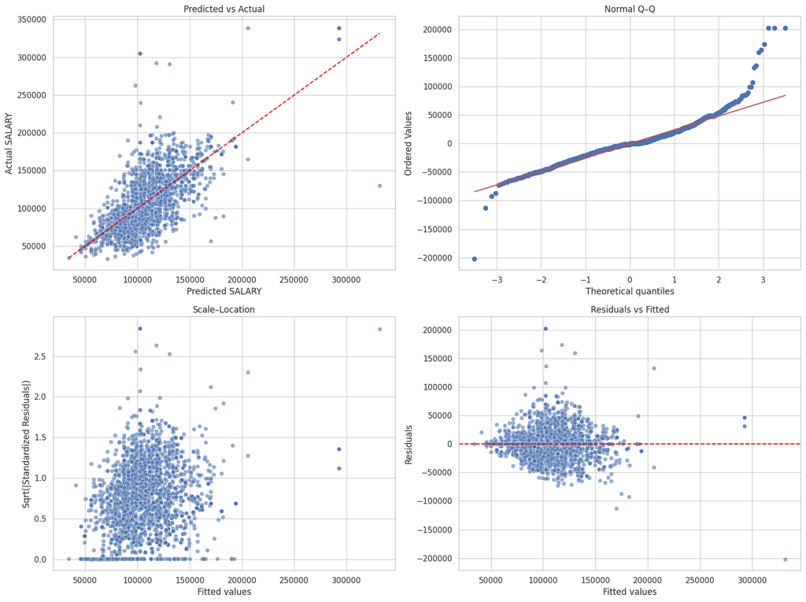

```python
#| eval: true
#| echo: false
import matplotlib.pyplot as plt
import seaborn as sns
import scipy.stats as stats

import numpy as np
import pandas as pd

# Load predictions from GLR model
df_pred = summary.predictions.select("prediction", "SALARY").toPandas()

# Compute residuals
df_pred["residuals"] = df_pred["SALARY"] - df_pred["prediction"]
df_pred["fitted"] = df_pred["prediction"]

# Standardized residuals
res_mean = np.mean(df_pred["residuals"])
res_std = np.std(df_pred["residuals"])
df_pred["std_residuals"] = (df_pred["residuals"] - res_mean) / res_std

# Square root of standardized residuals (for Scale–Location)
df_pred["sqrt_std_resid"] = np.sqrt(np.abs(df_pred["std_residuals"]))

# Plot grid setup
plt.figure(figsize=(16, 12))
sns.set_theme(style="whitegrid")

# Plot 1: Predicted vs Actual
plt.subplot(2, 2, 1)
sns.scatterplot(x="fitted", y="SALARY", data=df_pred, alpha=0.6)
plt.plot([df_pred["fitted"].min(), df_pred["fitted"].max()],
         [df_pred["fitted"].min(), df_pred["fitted"].max()],
         color="red", linestyle="--")
plt.xlabel("Predicted SALARY")
plt.ylabel("Actual SALARY")
plt.title("Predicted vs Actual")

# Plot 2: Normal Q–Q
plt.subplot(2, 2, 2)
stats.probplot(df_pred["residuals"], dist="norm", plot=plt)
plt.title("Normal Q–Q")

# Plot 3: Scale–Location (sqrt of standardized residuals vs fitted)
plt.subplot(2, 2, 3)
sns.scatterplot(x="fitted", y="sqrt_std_resid", data=df_pred, alpha=0.6)
plt.xlabel("Fitted values")
plt.ylabel("Sqrt(|Standardized Residuals|)")
plt.title("Scale–Location")

# Plot 4: Residuals vs Fitted
plt.subplot(2, 2, 4)
sns.scatterplot(x="fitted", y="residuals", data=df_pred, alpha=0.6)
plt.axhline(0, color="red", linestyle="--")
plt.xlabel("Fitted values")
plt.ylabel("Residuals")
plt.title("Residuals vs Fitted")

plt.tight_layout()
plt.savefig("_output/glr_diagnostic_classic.png")
plt.show()
```

The diagnostic plots help assess the assumptions and overall performance of the linear regression model. While the Predicted vs Actual plot suggests a moderately strong linear relationship, the Q-Q plot and Residuals vs Fitted plots reveal some deviation from normality and hints of heteroscedasticity—indicating that the model may benefit from further refinement or feature transformation to better capture salary variability.

# Evaluation

The evaluation of the model is crucial to understand its performance. In this section, we will calculate and visualize the following metrics:

1. **R² (Coefficient of Determination)**: Indicates how well the model explains the variance in the target variable.
2. **RMSE (Root Mean Squared Error)**: Measures the average magnitude of the errors between predicted and actual values.

```python
#| eval: true
#| echo: false

from pyspark.ml.evaluation import RegressionEvaluator
from pyspark.sql.functions import col, pow, sqrt, avg
import numpy as np

# 1. Predict on test data
pred_glr = lr_model.transform(test_data)

# 2. R² using evaluator
r2_eval = RegressionEvaluator(predictionCol="prediction", labelCol="SALARY", metricName="r2")
r2 = r2_eval.evaluate(pred_glr)


# 3. BIC manual calculation
n = pred_glr.count()                  # number of observations
k = len(lr_model.coefficients) + 1   # number of predictors including intercept

# Residual Sum of Squares (RSS)
rss = pred_glr.withColumn("sq_error", pow(col("SALARY") - col("prediction"), 2)) \
              .agg({"sq_error": "sum"}).collect()[0][0]


aic = n * np.log(rss / n) + 2 * k

bic = n * np.log(rss / n) + k * np.log(n)

# 5. RMSE manually
residuals_df = pred_glr.withColumn("squared_error", pow(col("SALARY") - col("prediction"), 2))
rmse = np.sqrt(residuals_df.agg(avg("squared_error")).first()[0])

# Print results
print(f"R² on Test Set: {r2:.4f}")
print(f"AIC from Training: {aic:.4f}")
print(f"BIC on Test Set: {bic:.4f}")
print(f"Manual RMSE on Test Set: {rmse:.4f}")
```

```
[Stage 74:>                                                         (0 + 1) / 1]
```

```
R² on Test Set: 0.4826
AIC from Training: 16033.3068
BIC on Test Set: 17510.4948
Manual RMSE on Test Set: 25724.9222
```

In this step, we quantitatively assessed model performance using R², AIC, BIC, and RMSE metrics. The R² value of 0.4826 suggests the model explains around 48% of the variance in salary, while the RMSE of 25,724.92 indicates the average error in predictions—highlighting that although the model captures some key trends, it leaves room for improvement in precision and generalization.

## Model Evaluation Plot

- Display the predicted vs actual salary plot with a red line indicating the ideal fit (y=x).
- Use `seaborn` or `matplotlib` to create the plot.
- Customize the plot with appropriate titles, labels, and legends.
- Describe the plot in a few sentences, highlighting key insights and observations.

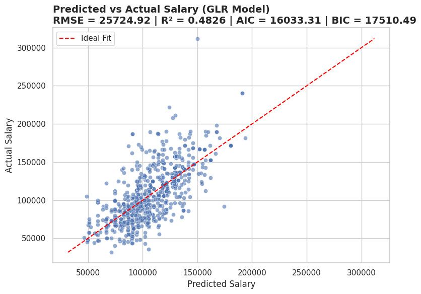

```python
#| eval: true
#| echo: false

# Convert predictions to pandas
pandas_df = pred_glr.select("prediction", "SALARY").toPandas()

# Plot
plt.figure(figsize=(8, 6))
sns.set_theme(style="whitegrid")

# Scatter plot of predicted vs actual
sns.scatterplot(data=pandas_df, x="prediction", y="SALARY", alpha=0.6)

# Add red identity line (ideal prediction)
min_val = min(pandas_df["prediction"].min(), pandas_df["SALARY"].min())
max_val = max(pandas_df["prediction"].max(), pandas_df["SALARY"].max())
plt.plot([min_val, max_val], [min_val, max_val], color="red", linestyle="--", label="Ideal Fit")

# Title with metrics
plt.title(
    f"Predicted vs Actual Salary (GLR Model)\n"
    f"RMSE = {rmse:.2f} | R² = {r2:.4f} | AIC = {aic:.2f} | BIC = {bic:.2f}",
    loc="left", fontsize=14, fontweight="bold"
)

# Axes labels
plt.xlabel("Predicted Salary")
plt.ylabel("Actual Salary")
plt.legend()
plt.tight_layout()

# Save + Show
plt.savefig("_output/glr_predicted_vs_actual.png", dpi=300)
plt.show()
```

This plot compares predicted salaries to actual values, with the red dashed line representing the ideal scenario (perfect predictions). While most predictions cluster around the line—indicating reasonable accuracy—there is visible dispersion and underestimation at higher salary ranges, suggesting that the model tends to struggle more with extreme values and could benefit from further refinement or feature enhancement.

# Submission {.unnumbered}

1. Save figures in the `_output/` folder.
2. Commit and push code and output files:

```
git add .
git commit -m "Add Lab 08 Salary Prediction models and output"
git push origin main
```

3. Submit your GitHub repository link.

# Resources {.unnumbered}

- [PySpark MLlib Docs](https://spark.apache.org/docs/latest/ml-guide.html)
- [Seaborn Docs](https://seaborn.pydata.org/)
- [Pandas User Guide](https://pandas.pydata.org/docs/user_guide/index.html)